# Exame de MOQ-13: PARTE 1

Problema 01 (5,0 pts)

Professora: Denise B. Ferrari

Aluno:

Vinícius de Pádua Dias Aráujo - Turma 22.2

Data: 22/11/2019

## Instruções:

1. As respostas serão avaliadas com relação à:
1. reprodutibilidade;
2. correção; e
3. completude da solução proposta, devendo incluir:

```
+ Enunciado do problema
+ Apresentação da estratégia de solução
+ Resultados (resumos numéricos e gráficos)
+ Análise dos resultados obtidos
+ Código R comentado
+ Referências (textos, sites etc.)
```

**OBS:**  
Existe um volume enorme de código disponível na internet para resolver praticamente qualquer problema. O reuso de código obtido online é permitido, desde que citada a fonte (mesmo que tenha sido utilizada apenas como inspiração…)

**Prazo: 06/12/2019**

**Entregáveis:**

- Todos os arquivos utilizados para realizar a tarefa, organizados em uma pasta, seguindo o modelo:

```
[Turma-22-X]_[Nome-Aluno]_Exame-P1
  |-data
  |-img
  |-[Turma-22-X]_[Nome-Aluno]_Exame-P1.html
  |-[Turma-22-X]_[Nome-Aluno]_Exame-P1.Rmd
```

- Submeter todo o material em uma pasta via **CLASSROOM**.

## Introdução

Em um pronto-atendimento oftalmológico há 2 consultórios médicos. A clínica abre às 9h e os pacientes chegam de acordo com um processo de Poisson com taxa 10min, ou seja, este é o tempo esperado de chegada do primeiro cliente após a abertura da clínica. Os pacientes podem ser atendidos indiscriminadamente por qualquer um dos plantonistas. Ao chegar na clínica, o paciente aguarda até que um dos médicos esteja disponível. A duração de cada consulta é uma variável aleatória uniformemente distribuída entre 5 e 20 minutos. A clínica deixa de admitir novos pacientes às 16h e fecha após terminado o atendimento do último paciente.

## PARTE 1: Estratégia de Solução Computacional

Para simular a fila, faz-se necessário o controle do estado do sistema entre cada instante que acontece um evento. Um evento é aqui definido como um acontecimento de chegada ou saída de cliente. O estado do sistema é definido pelo número de clientes na fila, número de clientes sendo atendidos e número de clientes que já foram atendidos. Cada processo de final de atendimento em cada consultorio, chegada de cliente, saída de cliente será marcado em variáveis discretas.

Toda vez que um cliente chega, será marcado esse tempo de chegada e então será verificado se há consultório livre. Marcam-se os acontecimentos de chegada por ordem de chegada dos pacientes para no final termos o tempo médio de espera. Além disso marcaremos o tempo de cada acontecimento, para obter o tempo a mais que o consultorio fica aberto, então, basta subtrair esse tempo do tempo total que a clinica fica aberta.

O código foi inspirada na aula [Introdução a Simulação Estocática em R](http://www-di.inf.puc-rio.br/~lopes//inf2035/Simul-Eventos.pdf)

## PARTE 2: Solução via Simulação de Monte Carlo

Solução Computacional

O código abaixo é baseado na estratégia computacional acima descrita.

```r
# Limpa a área de trabalho
Respostas <- function()
{
  rm(list = ls())
  lambda <- 1/10
  duracao <- 60*7 # de 9 a 16 se passam 7 horas
  t <- 0 #tempo percorrido
  n <- 0 #número de pessoas no sistema (fila + atendimento)
  ta <- c(rexp(1,rate = lambda)) #tempo de entrada de cada paciente por ordem de chegada
  td = NULL #tempo de partida de cada paciente por ordem de chegada
  tld <- c(Inf,Inf) # tempo da ultimo partida dos dois consultórios
  finished <- FALSE
  tempoMedioDeEspera = 0
  tempoFechou = 0 #tempo que o pronto atendimento terminou os atendimentos
  numeroPacientes = 0
  aguardou=0

  while(!finished){
    #As duas primeiras condicionais servem para ver a ordem dos acontecimentos, executando o código nessa ordem
    if ((ta[numeroPacientes+1] <= tld[1])&&(ta[numeroPacientes+1] <= duracao)) {
      t <- ta[numeroPacientes+1]
      numeroPacientes <- numeroPacientes+1
      n <- n+1
      #Claro que se um conaultório estiver desocupado quando o paciente chegar ele irá direto ao consultório
      if (n == 1 || n == 2) {
        tld[n] = t + runif(1, min = 5, max = 20)
        td <- c(td, tld[n])
        #Mantem-se sempre os tempos dos ultimos que sairam atualizados em ordem do menor para o maior
        tld = sort.int(tld)

        }
    ta <- c(ta, t + rexp(1,rate = lambda))
  }
  else if ((tld[1] < ta[numeroPacientes+1])&&(tld[1] <= duracao)) {
    t <- tld[1]
    n <- n-1
    #Se após a saída dessa pessoa tiver apenas uma ou nem uma pessoa, então o consultório fica vago e na proxima iteração não há prospecção de saída de paciente dele
    if (n == 0 || n == 1){
      tld[1] <- Inf
      tld = sort.int(tld)
    }
    else {
      td <- c(td, t + runif(1, min = 5, max = 20))
      aguardou=aguardou+1
    }
  }
    #Se um dos tempos ultrapassar o horário de duração então não há mais chegadas e repete-se o processo até não haver mais pacientes sobrando
  else if ((min(ta[numeroPacientes+1],tld[1]) > duracao) && (n > 0)) {
    while(n>0){
      t <- tld[1]
      n <- n-1
      if (n > 1)
        {
          tld[1] <- t + runif(1,min = 5.0, max = 20)
          td = c(td,tld[1])
          tld = sort.int(tld)
      }
      if(n==1)
      {
        tld[1] = Inf
        tld = sort.int(tld)
      }
    }
  }
  else {
      tempoFechou = max(t-duracao,0)
      finished = TRUE
    }
  }
  tempoMedioDeEspera=mean(td-ta[1:numeroPacientes])
  retorno=c(numeroPacientes,aguardou,tempoMedioDeEspera,tempoFechou)
}
```

## PARTE 3: Simulação de Monte Carlo

> Utilize simulação de Monte Carlo para analisar a qualidade do atendimento prestado aos pacientes. As soluções devem ser dadas em termos da mediana estimada e de intervalos (aproximados) de 95% de confiança construídos a partir de 100 replicações independentes para cada uma das perguntas nos itens acima.

> Não esqueça de fornecer resumos gráficos e numéricos para substanciar sua análise.

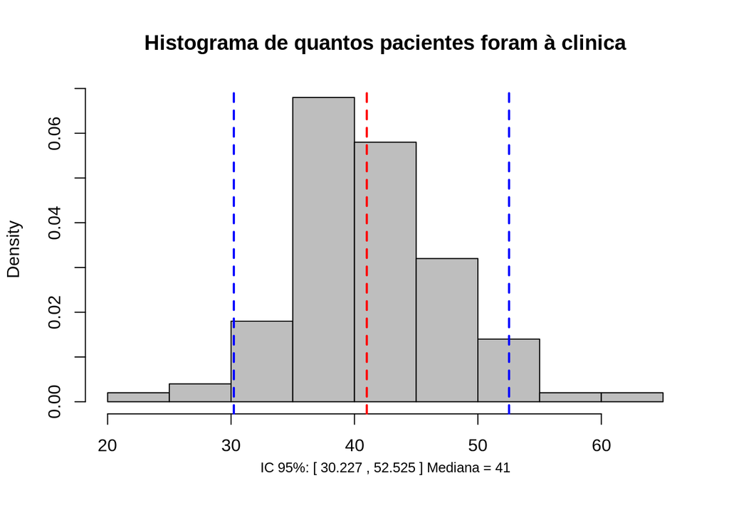

```r
numeroPacientes=rep(0,100)
aguardou=rep(0,100)
tempoMedioDeEspera=rep(0,100)
horaFechou=rep(0,100)

for (i in 1:100)
{
  t<-Respostas()
  numeroPacientes[i] = t[1]
  aguardou[i] = t[2]
  tempoMedioDeEspera[i] = t[3]
  horaFechou[i] = t[4]
}
#Visualização dos resutados

#Calcula das medianass
my.NumeroPacientes = round(median(numeroPacientes), 3)
my.Aguardaram = round(median(aguardou), 3)
my.TempoMedioDeEspera = round(median(tempoMedioDeEspera),3)
my.TempoFechamento = round(median(horaFechou), 3)

#Calculo dos intervalos de confiança de 95% para a mediana de cada resposta

numeroPacientes.IC95 <- round(quantile(numeroPacientes, probs = c(0.0225, 0.975)), 3)
aguardou.IC95 <- round(quantile(aguardou, probs = c(0.0225, 0.975)), 3)
tempoMedioDeEspera.IC95 <- round(quantile(tempoMedioDeEspera, probs = c(0.0225, 0.975)), 3)
horaFechou.IC95 <- round(quantile(horaFechou, probs = c(0.0225, 0.975)), 3)

#Construção dos histogramas dos resultados obtidos
  hist(numeroPacientes, freq = FALSE,
       xlab = "",
       col = "gray",
     main = "Histograma de quantos pacientes foram à clinica")
  #Anotações nos graficos
  mtext(paste("IC 95%: [", numeroPacientes.IC95[1],",", numeroPacientes.IC95[2], "]", "Mediana =", my.NumeroPacientes),
        side=1, line =2, cex = 0.8)
  abline(v = my.NumeroPacientes, col = 2, lwd = 2, lty = "dashed")
  abline(v = numeroPacientes.IC95,
         col = 4, lwd = 2, lty = "dashed")
```

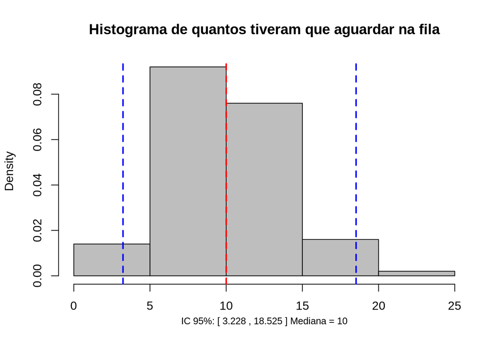

```r
  hist(aguardou, freq = FALSE,
       xlab = "",
       col = "gray",
     main = "Histograma de quantos tiveram que aguardar na fila")
  #Anotações nos graficos
  mtext(paste("IC 95%: [", aguardou.IC95[1],",", aguardou.IC95[2], "]", "Mediana =", my.Aguardaram),
        side=1, line =2, cex = 0.8)
  abline(v = my.Aguardaram, col = 2, lwd = 2, lty = "dashed")
  abline(v = aguardou.IC95,
         col = 4, lwd = 2, lty = "dashed")
```

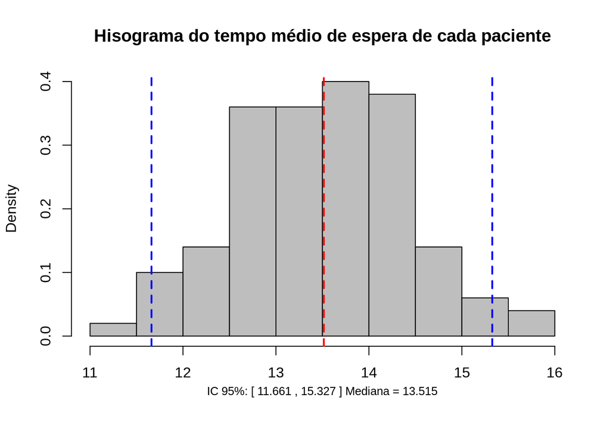

```r
  hist(tempoMedioDeEspera, freq = FALSE,
       xlab = "",
       col = "gray",
     main = "Hisograma do tempo médio de espera de cada paciente")
  #Anotações nos graficos
  mtext(paste("IC 95%: [", tempoMedioDeEspera.IC95[1],",", tempoMedioDeEspera.IC95[2], "]", "Mediana =", my.TempoMedioDeEspera),
        side=1, line =2, cex = 0.8)
  abline(v = my.TempoMedioDeEspera, col = 2, lwd = 2, lty = "dashed")
  abline(v = tempoMedioDeEspera.IC95,
         col = 4, lwd = 2, lty = "dashed")
```

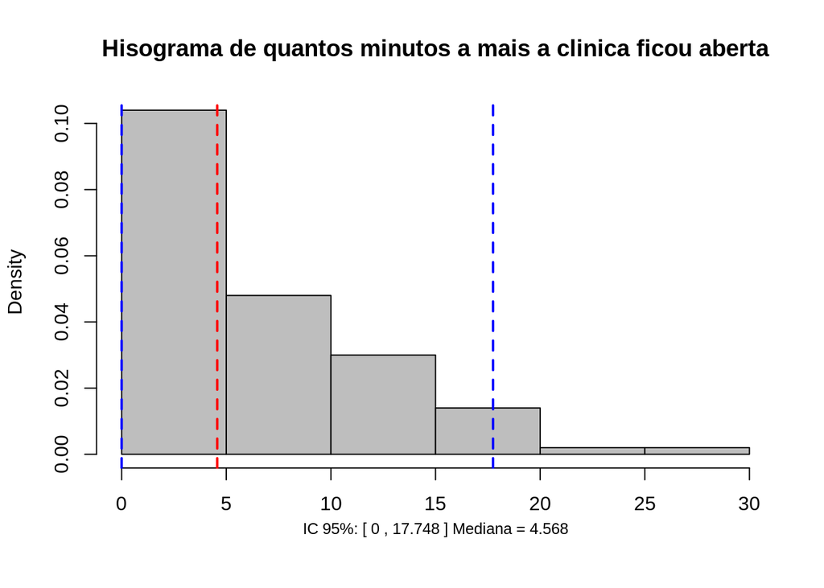

```r
  hist(horaFechou, freq = FALSE,
       xlab = "",
       col = "gray",
     main = "Hisograma de quantos minutos a mais a clinica ficou aberta")
  #Anotações nos graficos
  mtext(paste("IC 95%: [", horaFechou.IC95[1],",", horaFechou.IC95[2], "]", "Mediana =", my.TempoFechamento),
        side=1, line =2, cex = 0.8)
  abline(v = my.TempoFechamento, col = 2, lwd = 2, lty = "dashed")
  abline(v = horaFechou.IC95,
         col = 4, lwd = 2, lty = "dashed")
```